5 min read

# Comic Options for R Output

2016-07-20

# Comic Options for R Output

Kent Russell

2016-07-20

In this [Ted Talk](http://www.ted.com/talks/scott_mccloud_on_comics?language=en) and his book [Understanding Comics](http://www.amazon.com/Understanding-Comics-The-Invisible-Art/dp/006097625X), Scott McCloud discusses his theory of iconic identification. In his theory he claims that we identify more with cartoons and icons than realistic images and words. Assuming this is true and assuming that it can be applied to output from `R`, some package authors have offered some packages to cartoonize `R` graphs. I doubt seriously that this is a complete list.

1. [xkcd](http://cran.r-project.org/web/packages/xkcd/index.html)
2. [phytools `xkcdTree`](http://www.phytools.org/static.help/xkcdTree.html)
3. [RXKCD](http://cran.r-project.org/web/packages/RXKCD/index.html)

For even more fun, here is [xkcd in Fortran](http://implicitnone.com/xkcd-plots-fortran/).

Despite the above list, there is still not a comprehensive option in R to cartoonize images, so I thought I would try to tackle cartoonizing with `comicR` leveraging [`comic.js`](https://github.com/balint42/comic.js). This little `htmlwidget` is far from comprehensive, but it can apply to nearly all `R` graphical output.

### Installation

`comicR` is not on CRAN, so please install with `devtools::install_github()` as demonstrated below.

```r
devtools::install_github("timelyportfolio/comicR")
```

### Base `graphics`

Handwritten fonts with `extrafont` such as [Permanent Marker](https://www.google.com/fonts/specimen/Permanent+Marker) from Google webfonts and setting `lty=2,lwd=2` gets us pretty close to a cartoon-like graph.

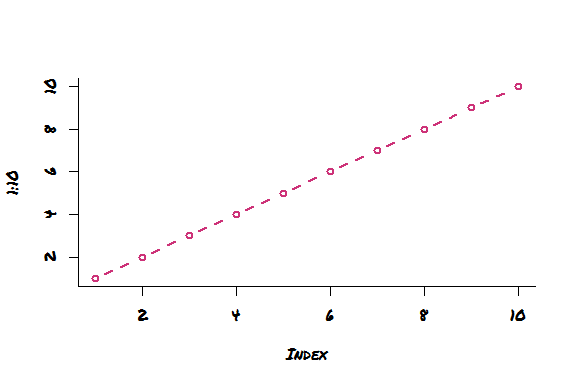

```r
library(extrafont)

plot(
  1:10, type = "b", bty = "l", col="violetred3"
  , family = "Permanent Marker" # use Permanent Marker font from Google Fonts
  , lty = 2, lwd = 2            # darker and dashed lines look more comic like to me
)
```

You might notice though the axes are too straight for a cartoon. `comicR` with some `SVG` and [`comic.js`](https://github.com/balint42/comic.js) magic will complete the effect. The packages `SVGAnnotation`, `XML`, and `htmltools` will also be very helpful in our cartoon quest. **Note: currently not working in RStudio Viewer**.

```r
library(htmltools)
library(SVGAnnotation)
library(XML)
library(comicR)

tagList(
  tags$div(
    id = "comic_noconfig"
    ,tags$h3( "comicR with defaults" )
    ,HTML(
      saveXML(
        svgPlot({plot(1:10, type = "b", bty = "l", col="paleturquoise3")}, height=4, width = 6)
      )
    )
  )
  ,comicR( "#comic_noconfig" )
  ,tags$div(
    id = "comic_withconfig"
    ,tags$h3( "comicR with ff config = 3" )
    ,HTML(
      #  handle glyph id conflicts
      gsub(
        x = saveXML(
          svgPlot({plot(1:10, type = "b", bty = "l", col="plum3")}, height=4, width = 6)
        )
        , pattern = "glyph"
        , replacement = "svg2-glyph"
      )
    )
  )
  ,comicR( "#comic_withconfig", ff = 3 )
  ,tags$div(
    id = "justr-withcomic"
    ,tags$h3( "comicR + extrafont Permanent Marker" )
    ,HTML(
      #  handle glyph id conflicts
      gsub(
        x = saveXML(
          svgPlot(
            {
              plot(1:10, type = "b", bty = "l", col="chocolate3"
               , family = "Permanent Marker" # use Permanent Marker font from Google Fonts
               , lty = 2, lwd = 2            # darker and dashed lines look more comic like to me
              )
            }
            , height=4, width = 6
          )
        )
        , pattern = "glyph"
        , replacement = "svg4-glyph"
      )
    )
  )
  ,comicR( "#justr-withcomic", ff=5 )
)
```

### comicR with defaults

[figure not shown]

[interactive chart not shown]

### comicR with ff config = 3

[figure not shown]

[interactive chart not shown]

### comicR + extrafont Permanent Marker

[figure not shown]

[interactive chart not shown]

### Lattice graphics

```r
library(lattice)
library(gridSVG)
library(pipeR)

dev.new( height = 10, width = 10, noRStudioGD = T )
dev.set(which = tail(dev.list(),1))
```

```r
dotplot(variety ~ yield | year * site, data=barley)
dot_svg <- grid.export(name="")$svg
dev.off()
```

```r
tagList(
  tags$div(
    id = "lattice-comic"
    ,tags$h3("lattice plot with comicR and Google font")
    ,HTML(saveXML(addCSS(
      dot_svg
      , I("svg text { font-family : Architects Daughter; }")
    )))
  )
  ,comicR( "#lattice-comic", ff = 5 )
)# %>>%
```

### lattice plot with comicR and Google font

[figure not shown]

[interactive chart not shown]

```r
#  attachDependencies(
#    htmlDependency(
#      name = "ArchitectsDaughter"
#      ,version = "0.1"
#      ,src = c(href='http://fonts.googleapis.com/css?family=Architects+Daughter')
#      ,stylesheet = ""
#    )
#  )
```

### DiagrammeR graphics

```r
library(DiagrammeR)
library(DiagrammeRsvg)

#  using example from DiagrammeR Readme.md
#  https://github.com/rich-iannone/DiagrammeR
grViz("
digraph boxes_and_circles {

  # a 'graph' statement
  graph [overlap = true]

  # several 'node' statements
  node [shape = box,
        fontname = Helvetica]
  A; B; C; D; E; F

  node [shape = circle,
        fixedsize = true,
        width = 0.9] // sets as circles
  1; 2; 3; 4; 5; 6; 7; 8

  # several 'edge' statements
  A->1; B->2; B->3; B->4; C->A
  1->D; E->A; 2->4; 1->5; 1->F
  E->6; 4->6; 5->7; 6->7; 3->8
}
") %>>%
  export_svg %>>%
  (
    tagList(
      tags$div(
        id = "diagrammer_example"
        ,tags$style("#diagrammer_example text {font-family:Permanent Marker;}")
        ,tags$h3("comicR + DiagrammeR")
        ,HTML(.)
        ,comicR("#diagrammer_example", ff=3)
      )
    )
  )
```

```
## pre-main prep time: 5 ms
```

### comicR + DiagrammeR

[figure not shown]

[interactive chart not shown]

### Thanks

Thanks so much

- [`comic.js`](https://github.com/balint42/comic.js) from Balint Morvai
- Ramnath Vaidyanathan and RStudio for `htmlwidgets`
- all the contributors to `R` and `JavaScript`